# SCLC RNA-seq Batch Correction

### Make new combined dataset of CCLE and Minna data

The raw CCLE data is in estimated transcript abundace (linear scale) whereas the Minna data have already been converted to log scale. To best remove the differences between these datasets that is due technical variation we will use Surrogate Variable Analysis (`SVA`), which is a common way to do this for RNA-seq data.

We want to use the CCLE and Minna RNA-seq datasets only since the GDSC data is from microarray and would likely have a significantly different type/amount of technical variation.

Since we are interested in identifying genes that distinguish the subtypes/phenotypes we will make two models, one containing the subtypes and one without (nested models) to identify features that are not attributable to differences in phenotypes.

First, we will load both datasets.

`r`r cfstpath <- file.path(‘/mnt/vu1file/Data/RNAseq/CCLE (all data)/CCLE_RNAseq_rsem_genes_tpm_20180929.txt.fst’)

gtf <- readGFF(/mnt/vu1file/Data/RNAseq/CCLE (all data)/gencode.v19.genes.v7_model.patched_contigs.gtf.gz, version=2L) # keep only coding genes gtf <- gtf[gtf$gene_type==‘protein_coding’,]

d <- read.fst(cfstpath) # clean CCLE data d <- cleanCCLEdata(d)

# load Minna data

m <- read.csv(file.path(‘../data/cBioPortal_data_Minna_mRNA-seq.csv’),as.is=TRUE) m <- cleanMinnaData(m)

commongenes <- intersect(rownames(d),rownames(m))

# CCLE data

ctemp <- as.data.frame(d) colnames(ctemp) <- paste0(‘c.’,colnames(ctemp))

# Minna data

mtemp <- m colnames(mtemp) <- paste0(‘m.’,colnames(mtemp))

# combine all data, using only common genes

ad <- do.call(cbind, list(mtemp[commongenes,],ctemp[commongenes,]))

# # load variable genes used for clustering (determined previously)

# vargenes <- read.csv(file=‘../data/variable_genes.csv’,as.is=TRUE)[,1]

# # remove genes from vargenes not present in data

# vargenes <- vargenes[vargenes %in% rownames(ad)]

# # find genes where values across all samples are < 2

lowgenes <- rownames(ad)[apply(ad, 1, function(x) all(x<2))]

# # save gene expression values of only variable genes in linear and log2 scale

# gev <- as.matrix(ad[vargenes,])

gev <- as.matrix(ad[!rownames(ad) %in% lowgenes,])

l2gev <- log2(gev)

# load subtype/clustering information

subtype_info <- read.csv(‘../data/combined_clusters.csv’,as.is=TRUE, row.names=1) phen <- subtype_info[colnames(ad),c(‘cell.line’,‘source’,‘id’,‘phenotype’)]

First, examine histograms of gene expression values from each dataset.

`r`r h <- lapply(c(‘m’,‘c’), function(x) { sstr <- paste0(‘^’,x) hist(l2gev[,grep(sstr,colnames(l2gev))],breaks=seq(-2,15,.1), plot=TRUE, freq = FALSE, xlab=‘gene exp value’, main=x) })

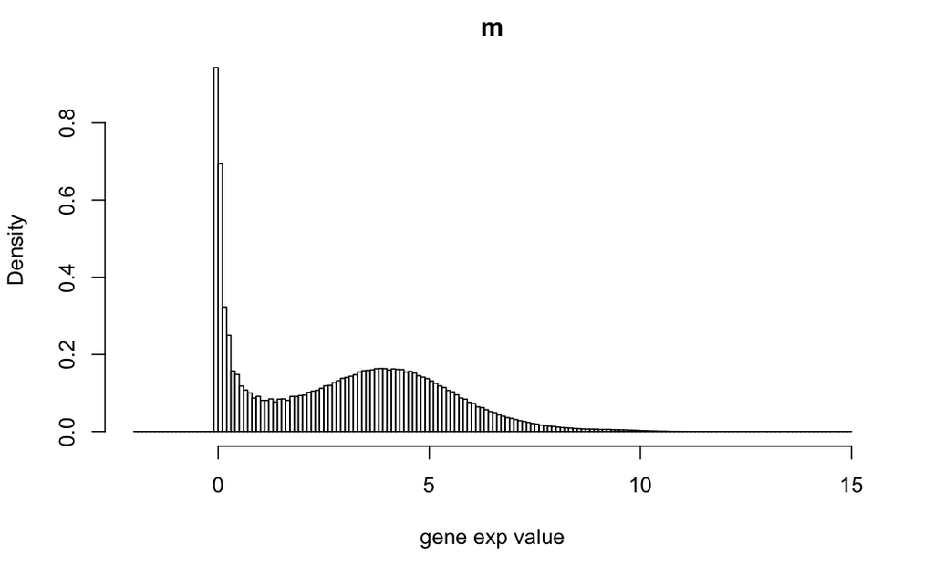

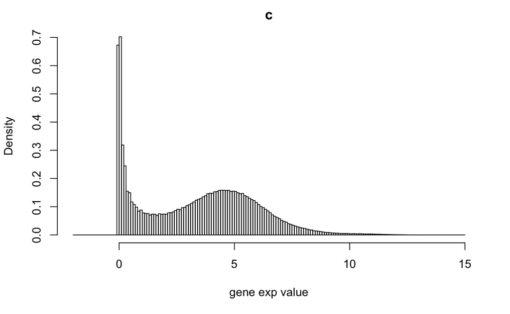

#### Assess differences in gene distributions

Examine the distributions of gene expression values (by sample) across the datasets.

`r`r matdensity(l2gev, groupFactor=substr(colnames(l2gev),1,1))

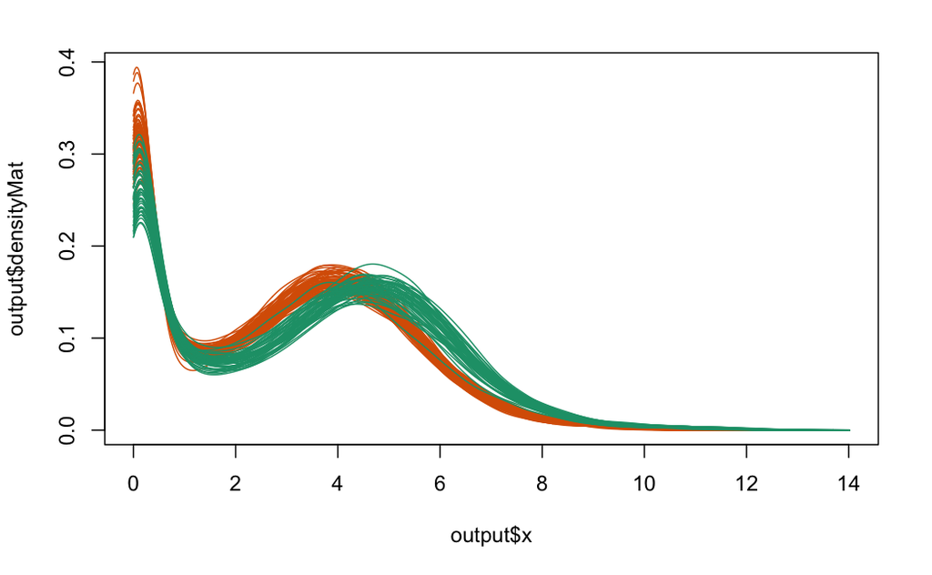

#### Detect/correct batch effects

Can use `BatchQC` to determine/visualize batch effects. Once run, does not need to be repeated (files saved).

#### Remove batch effects using Surrogate Variable Analysis

The Bioconductor package `sva` can be used to directly remove batch effects using a Bayesian approach, `ComBat` (Johnson et al. 2007 Biostatistics). The `sva` package assumes there are two types of variables that are being considered:

1. Adjustment variables
2. Variables of interest

Two model matrices must be made: the “full model” and the “null model”. The null model is a model matrix that includes terms for all of the adjustment variables but not the variables of interest. The full model includes terms for both the adjustment variables and the variables of interest.

The model matrices can be created using the `model.matrix` function.

`r`r condition <- subtype_info[match(colnames(gev),rownames(subtype_info)),‘phenotype’] mod <- model.matrix(~ as.factor(condition), data=phen) mod0 <- model.matrix(~ 1, data=phen)

If the `sva` function is called without the *n.sv* argument specified, the number of factors will be estimated. The number of factors can also be estimated using the `num.sv` function.

The `sva` function returns a list with four components, `sv`, `pprob.gam`, `pprob.b`, `n.sv`.

- `sv` is a matrix whose columns correspond to the estimated surrogate variables.
- `pprob.gam` is the posterior probability that each gene is associated with one or more latent variables.
- `pprob.b` is the posterior probability that each gene is associated with the variables of interest.
- `n.sv` is the number of surrogate variables estimated by the sva.

[output not shown]

`r`r plot(svobj$sv, pch=19)

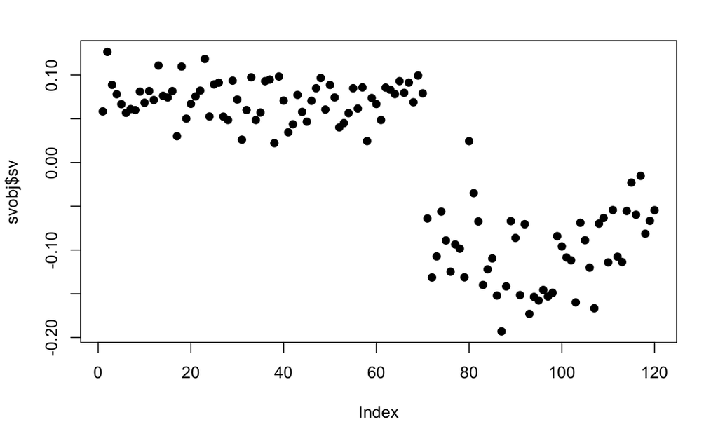

#### Generate batch-corrected data

“Frozen” surrogate variable analysis can be used to remove latent variation in the test data set. The training data is adjusted using the calculated surrogate variables. The testing data is adjusted using the “frozen” surrogate variable algorithm. The output of the `fsva` function is an adjusted training set and an adjusted test set. Using the log2 gene expression values (`l2gev`) as both training and test data should produce “batch corrected” data as output. This will be saved in the object `l2gev_bc`.

`r`r fsvaobj <- fsva(l2gev, mod, svobj, l2gev) l2gev_bc <- fsvaobj$new

Check batch correction using `matdensity` function.

`r`r matdensity(l2gev_bc, groupFactor=substr(colnames(l2gev_bc),1,1))

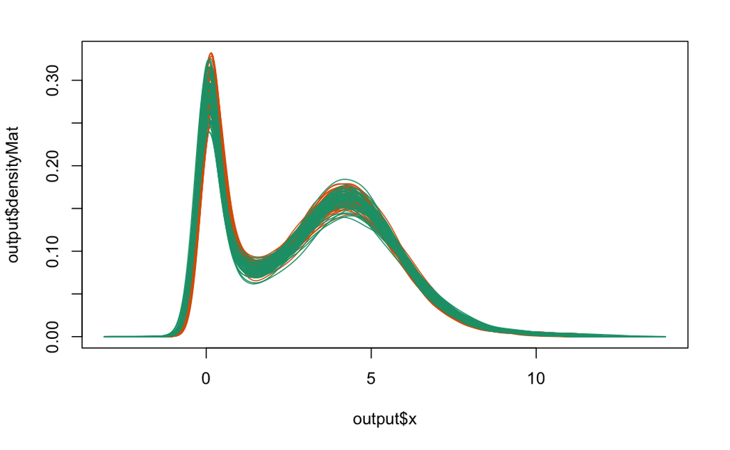

#### Save batch-corrected data

To prevent having to correct the batch effects every time, the batch-corrected data will be saved to a file (`../data/SCLC_combined_Minna_CCLE_batch_corrected_vargenes.csv`). NOTE: This file does not have all genes! (limited to the 15,950 genes not in `lowgenes`.)

`r`r # write.csv(l2gev_bc, # file=../data/SCLC_combined_Minna_CCLE_batch_corrected_vargenes.csv)

### Attempt to incorporate GDSC data

The batch correction seems to have worked very well with the RNA-seq data. Let’s try to do the bacth correction using all data, including the microarray data from GDSC. This code should run even without access to `vu1file`.

```r
# make temp data from cell lines present in at least 2 sources
# temp <- as.matrix(ccld[,gsub("[mcg]\\.", "", colnames(ccld)) %in% ccl])
temp <- temp[!apply(ccld,1, function(x) any(is.na(x))),]
```

```
Error in temp[!apply(ccld, 1, function(x) any(is.na(x))), ] :
  (subscript) logical subscript too long
```

```r
condition <- subtype_info[match(colnames(temp),rownames(subtype_info)),'phenotype']
mod <- model.matrix(~ as.factor(condition), data=phen)
mod0 <- model.matrix(~ 1, data=phen)

n.sv <- num.sv(temp,mod,method="leek")
svobj <- sva(temp,mod,mod0,n.sv=n.sv)
```

```
Number of significant surrogate variables is:  1
Iteration (out of 5 ):1  2  3  4  5
```

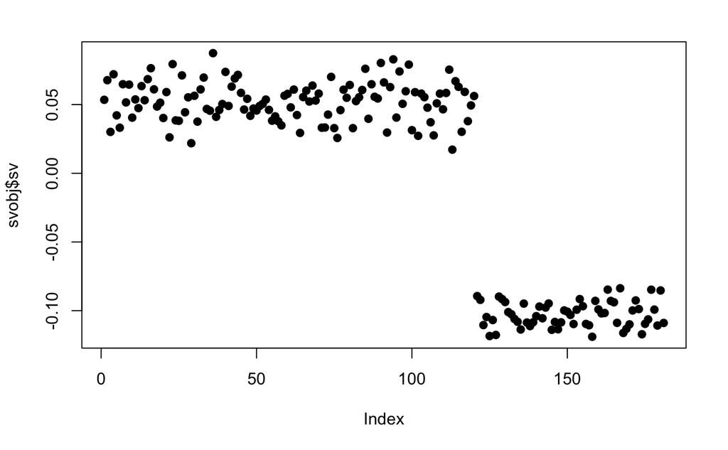

```r
plot(svobj$sv, pch=19)
```

```r
# as.matrix(z[rownames(z) %in% rownames(ccld),])
fsvaobj <- fsva(temp, mod, svobj, temp)
ccld_bc <- fsvaobj$new
```

Check batch correction using `matdensity` function.

[figure not shown]

```r
matdensity(ccld_bc,
           groupFactor=substr(colnames(ccld_bc),1,1), xlab="log2(expression)",
           ylab="density")
legend("topright", legend=c("Minna", "GDSC", "CCLE"),
       col=RColorBrewer::brewer.pal(8, "Dark2")[1:3], lwd=3)
```

### Compare to original

[figure not shown]

```r
matdensity(as.matrix(ccld),
           groupFactor=substr(colnames(ccld),1,1), xlab="log2(expression)",
           ylab="density")
```

[figure not shown]